# Homework 2: Forecasting With Regression

#Selin Gül - 2018402216

The aim of this homework is forecasting the sales of Unleaded gasoline sale (UGS) for every quarter of 2007 by using time series regression methods. We’re given gasoline and diesel sales (in 1000 m3) of a major distributor between 2000 and 2006 and several potential independent variables related to the objective variable. The statistical characteristics of the data are examined and the linear regression model is implement to forecast the asked sales.

Required packages are installed first:

```r
library(readxl)
library(lubridate)
library(zoo)
```

```r
library(ggplot2)
library(RcppRoll)
library(GGally)
library(skimr)
library(forecast)
library(dplyr)
library(data.table)
```

## 1) Data Gathering and Manipulations

```r
data_UGS <- read_excel("/Users/Macbook/Desktop/IE360_Spring22_HW2_data.xlsx")

colnames(data_UGS)= c("Quarter","UGS","RNUV","NLPG","PU","PG","NUGV","NDGV",
                "GNPA","GNPC","GNP")
data_UGS$Quarter= as.Date(as.yearqtr(data_UGS$Quarter,format="%Y_Q%q"))
head(data_UGS)
```

```
## # A tibble: 6 x 11
##   Quarter       UGS   RNUV   NLPG    PU    PG   NUGV   NDGV   GNPA   GNPC    GNP
##   <date>      <dbl>  <dbl>  <dbl> <dbl> <dbl>  <dbl>  <dbl>  <dbl>  <dbl>  <dbl>
## 1 2000-01-01 1.13e6 0.0146 940000  469.  356. 4.65e6 2.82e6 1.04e6 3.48e6 1.80e7
## 2 2000-04-01 1.20e6 0.0205 941000  459.  345. 4.74e6 2.84e6 1.76e6 4.53e6 2.18e7
## 3 2000-07-01 1.37e6 0.0207 943500  440.  327. 4.84e6 2.87e6 6.97e6 5.92e6 3.01e7
## 4 2000-10-01 1.13e6 0.0163 948000  402.  301. 4.92e6 2.88e6 3.27e6 4.93e6 2.45e7
## 5 2001-01-01 1.03e6 0.0071 950000  412.  306. 4.95e6 2.88e6 1.00e6 3.42e6 1.58e7
## 6 2001-04-01 1.02e6 0.0051 955000  520.  375. 4.98e6 2.88e6 1.45e6 4.36e6 2.03e7
```

The variables:

UGS: Unleaded gasoline sale for the given quarter

RNUV: An index that indicates the rate of new unleaded gasoline by using vehicles being added to the traffic in a quarter

PU: Average price (adjusted with an index) of a liter of unleaded gasoline for the given quarter

PG: Average price (adjusted with an index) of a liter of diesel gasoline for the given quarter

NUGV: Number of unleaded gasoline using vehicles in the traffic

NDGV: Number of diesel gasoline using vehicles in the traffic (per 1000 people)

GNPA: Agriculture component of Gross National Product (adjusted with an index)

GNPC: Commerce component of Gross National Product (adjusted with an index)

GNP: Grand total for GNP (agriculture, commerce and other components total)

## 2) Data Visualizations Before Regression

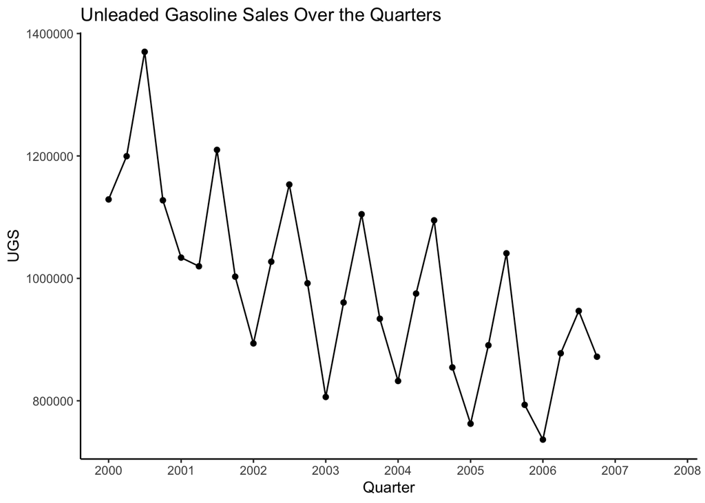

```r
ggplot(data_UGS, aes(x=Quarter,y=UGS))+geom_line()+geom_point()+
  labs(title = "Unleaded Gasoline Sales Over the Quarters")+theme_classic()+scale_x_date(date_breaks = "1 year", date_labels = "%Y")
```

The declining behavior with respect to time in the data can be seen easily at first sight. Also, the sharp increase in third quarter for every year can be the indication of the seasonality.

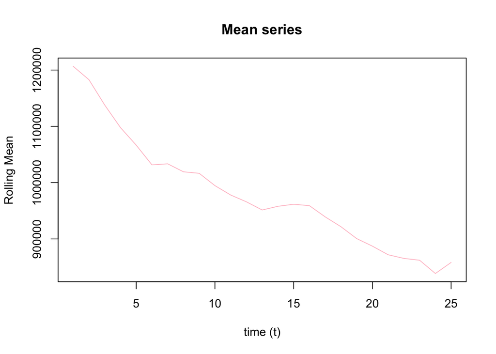

```r
meanOfSales=roll_mean(data_UGS$UGS[1:28],4,align='left')
varOfSales=roll_var(data_UGS$UGS[1:28],4,align='left')
plot(meanOfSales,
     type='l',col='pink',
     xlab = "time (t)",
     ylab = "Rolling Mean",
     main = "Mean series")
```

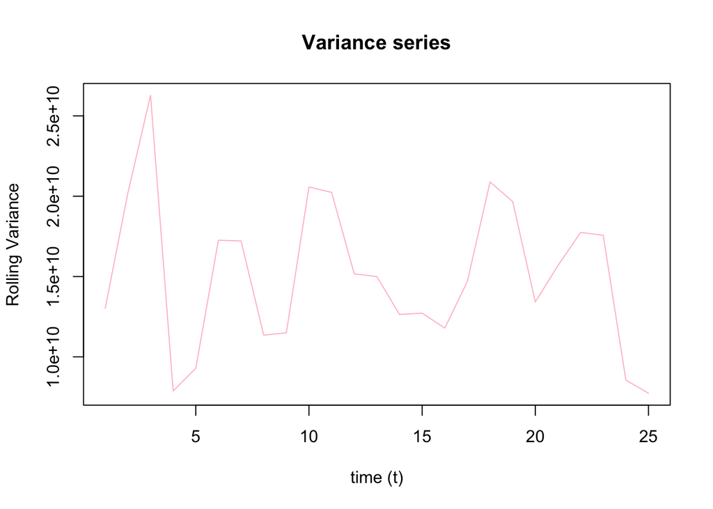

```r
plot(varOfSales,
     type='l',col='pink',
     xlab = "time (t)",
     ylab = "Rolling Variance",
     main = "Variance series")
```

From the rolling mean series of UGS, it’s obvious that the data isn’t stationary. However, we have no clear clue if the data is non-stationary with respect to its variance just by looking to the rolling variance of it.

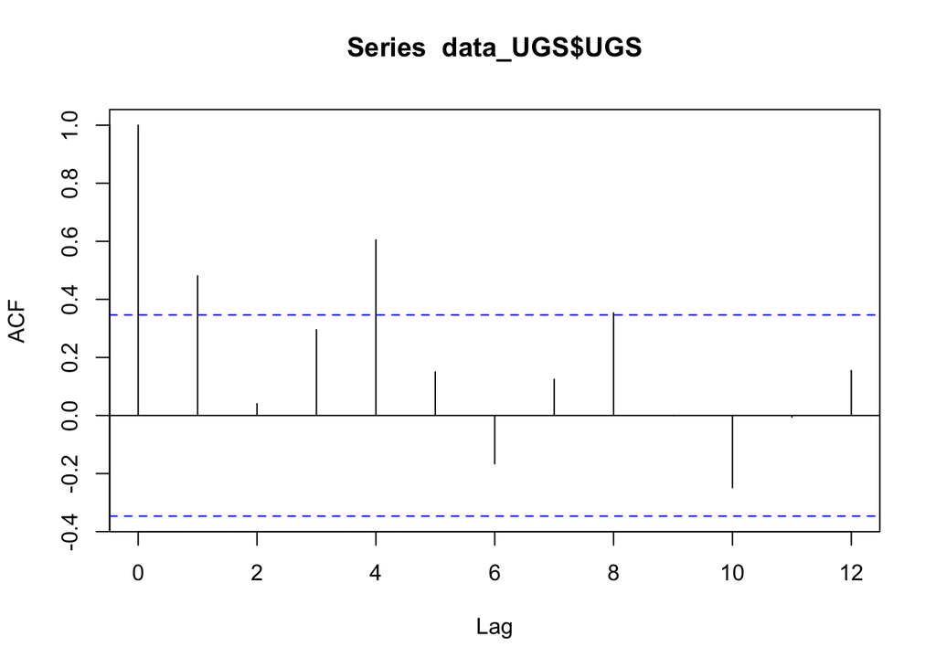

```r
acf(data_UGS$UGS,lag.max=12,na.action=na.pass)
```

There is a high auto-correlation at lag 1 and lag 4, which can be indication about the trend and seasonality in the data respectively.

## 3) Model Building for Linear Regression

In this step, the variables and two lag conditions will be added one by one and the Adjusted R-squared and p-values will be examined. If the added variable has a significant effect, meaning that it has a relatively high impact on the increasing value of the Adjusted R-squared and decreasing value of p-value, then it will remain in the model and the next variable will be tried with the same sequence. Also note that the seasonality variable is added as ‘Quarter’ and trend variable as ‘Trend’, which is as a series from 1 to 32.

```r
Quarter=seq(1,4,by=1)
data_UGS=cbind(data_UGS,Quarter)
modelQuarters=lm(UGS~Quarter,data=data_UGS)
summary(modelQuarters)
```

```
##
## Call:
## lm(formula = UGS ~ Quarter, data = data_UGS)
##
## Residuals:
##     Min      1Q  Median      3Q     Max
## -199873  -73453  -21971   71303  237234
##
## Coefficients:
##               Estimate Std. Error t value Pr(>|t|)
## (Intercept) 2678294.56  348665.34   7.682 3.76e-08 ***
## Quarter        -138.73      28.55  -4.859 4.88e-05 ***
## ---
## Signif. codes:  0 '***' 0.001 '**' 0.01 '*' 0.05 '.' 0.1 ' ' 1
##
## Residual standard error: 111400 on 26 degrees of freedom
##   (4 observations deleted due to missingness)
## Multiple R-squared:  0.4759, Adjusted R-squared:  0.4558
## F-statistic: 23.61 on 1 and 26 DF,  p-value: 4.875e-05
```

Seasonality(Quarter) has a strong correlation with UGS and it will be in the model.

```r
Trend=seq(1,32,by=1)
data_UGS=cbind(data_UGS,Trend)
modelTrend=lm(UGS~Quarter+Trend,data=data_UGS)
summary(modelTrend)
```

```
##
## Call:
## lm(formula = UGS ~ Quarter + Trend, data = data_UGS)
##
## Residuals:
##     Min      1Q  Median      3Q     Max
## -130962  -50165    3623   46175  186841
##
## Coefficients:
##               Estimate Std. Error t value Pr(>|t|)
## (Intercept) 1510634289  285724269   5.287 1.78e-05 ***
## Quarter        -138923      26297  -5.283 1.80e-05 ***
## Trend         12671554    2400978   5.278 1.82e-05 ***
## ---
## Signif. codes:  0 '***' 0.001 '**' 0.01 '*' 0.05 '.' 0.1 ' ' 1
##
## Residual standard error: 78150 on 25 degrees of freedom
##   (4 observations deleted due to missingness)
## Multiple R-squared:  0.7521, Adjusted R-squared:  0.7323
## F-statistic: 37.92 on 2 and 25 DF,  p-value: 2.681e-08
```

Trend variable was added and it has also important effect on increased Adjusted R-squared and decreased p-value, it will be in the final model.

```r
modelRNUV =lm(UGS~Quarter+Trend+RNUV,data=data_UGS)
summary(modelRNUV)
```

```
##
## Call:
## lm(formula = UGS ~ Quarter + Trend + RNUV, data = data_UGS)
##
## Residuals:
##     Min      1Q  Median      3Q     Max
## -109915  -47757   -9198   47266  156634
##
## Coefficients:
##               Estimate Std. Error t value Pr(>|t|)
## (Intercept) 1486629143  252221064   5.894 4.42e-06 ***
## Quarter        -136719      23213  -5.890 4.47e-06 ***
## Trend         12470272    2119441   5.884 4.54e-06 ***
## RNUV           6226320    2185200   2.849  0.00885 **
## ---
## Signif. codes:  0 '***' 0.001 '**' 0.01 '*' 0.05 '.' 0.1 ' ' 1
##
## Residual standard error: 68950 on 24 degrees of freedom
##   (4 observations deleted due to missingness)
## Multiple R-squared:  0.8148, Adjusted R-squared:  0.7916
## F-statistic: 35.19 on 3 and 24 DF,  p-value: 5.987e-09
```

RNUV variable was added and it has important effect on increased Adjusted R-squared and decreased p-value, it will be in the final model.

```r
modelNLPG =lm(UGS~Quarter+Trend+RNUV+NLPG,data=data_UGS)
summary(modelNLPG)
```

```
##
## Call:
## lm(formula = UGS ~ Quarter + Trend + RNUV + NLPG, data = data_UGS)
##
## Residuals:
##     Min      1Q  Median      3Q     Max
## -106923  -44305    7125   41792  122488
##
## Coefficients:
##               Estimate Std. Error t value Pr(>|t|)
## (Intercept)  1.696e+09  2.659e+08   6.381 1.64e-06 ***
## Quarter     -1.561e+05  2.447e+04  -6.376 1.66e-06 ***
## Trend        1.422e+07  2.232e+06   6.373 1.67e-06 ***
## RNUV         2.854e+06  2.769e+06   1.031   0.3133
## NLPG         3.916e-01  2.118e-01   1.849   0.0774 .
## ---
## Signif. codes:  0 '***' 0.001 '**' 0.01 '*' 0.05 '.' 0.1 ' ' 1
##
## Residual standard error: 65720 on 23 degrees of freedom
##   (4 observations deleted due to missingness)
## Multiple R-squared:  0.8387, Adjusted R-squared:  0.8107
## F-statistic:  29.9 on 4 and 23 DF,  p-value: 8.205e-09
```

NLPG variable was added and it has important effect on increased Adjusted R-squared, it will be in the final model.

```r
modelPU =lm(UGS~Quarter+Trend+RNUV+NLPG+PU,data=data_UGS)
summary(modelPU)
```

```
##
## Call:
## lm(formula = UGS ~ Quarter + Trend + RNUV + NLPG + PU, data = data_UGS)
##
## Residuals:
##     Min      1Q  Median      3Q     Max
## -102649  -42938    6609   39417  122537
##
## Coefficients:
##               Estimate Std. Error t value Pr(>|t|)
## (Intercept)  1.698e+09  2.717e+08   6.250 2.73e-06 ***
## Quarter     -1.562e+05  2.501e+04  -6.246 2.76e-06 ***
## Trend        1.424e+07  2.281e+06   6.243 2.78e-06 ***
## RNUV         2.984e+06  2.897e+06   1.030    0.314
## NLPG         3.795e-01  2.242e-01   1.693    0.105
## PU          -7.814e+01  3.785e+02  -0.206    0.838
## ---
## Signif. codes:  0 '***' 0.001 '**' 0.01 '*' 0.05 '.' 0.1 ' ' 1
##
## Residual standard error: 67130 on 22 degrees of freedom
##   (4 observations deleted due to missingness)
## Multiple R-squared:  0.839,  Adjusted R-squared:  0.8025
## F-statistic: 22.94 on 5 and 22 DF,  p-value: 4.768e-08
```

Since adding PU variable has very small and reducing effect on Adjusted R-squared, it will not be on the final model.

```r
modelPG =lm(UGS~Quarter+Trend+RNUV+NLPG+PG,data=data_UGS)
summary(modelPG)
```

```
##
## Call:
## lm(formula = UGS ~ Quarter + Trend + RNUV + NLPG + PG, data = data_UGS)
##
## Residuals:
##     Min      1Q  Median      3Q     Max
## -105495  -44021    6718   40799  122753
##
## Coefficients:
##               Estimate Std. Error t value Pr(>|t|)
## (Intercept)  1.696e+09  2.718e+08   6.240 2.80e-06 ***
## Quarter     -1.560e+05  2.502e+04  -6.235 2.83e-06 ***
## Trend        1.422e+07  2.282e+06   6.232 2.84e-06 ***
## RNUV         2.939e+06  2.961e+06   0.992    0.332
## NLPG         3.850e-01  2.272e-01   1.694    0.104
## PG          -4.952e+01  5.119e+02  -0.097    0.924
## ---
## Signif. codes:  0 '***' 0.001 '**' 0.01 '*' 0.05 '.' 0.1 ' ' 1
##
## Residual standard error: 67180 on 22 degrees of freedom
##   (4 observations deleted due to missingness)
## Multiple R-squared:  0.8388, Adjusted R-squared:  0.8022
## F-statistic: 22.89 on 5 and 22 DF,  p-value: 4.845e-08
```

Since adding PG variable has very small and reducing effect on Adjusted R-squared, it will not be on the final model.

```r
modelNUGV =lm(UGS~Quarter+Trend+RNUV+NLPG+NUGV,data=data_UGS)
summary(modelNUGV)
```

```
##
## Call:
## lm(formula = UGS ~ Quarter + Trend + RNUV + NLPG + NUGV, data = data_UGS)
##
## Residuals:
##     Min      1Q  Median      3Q     Max
## -116539  -42103     375   42289  130605
##
## Coefficients:
##               Estimate Std. Error t value Pr(>|t|)
## (Intercept)  1.711e+09  2.718e+08   6.294 2.47e-06 ***
## Quarter     -1.574e+05  2.503e+04  -6.289 2.49e-06 ***
## Trend        1.434e+07  2.282e+06   6.287 2.51e-06 ***
## RNUV         2.334e+06  3.000e+06   0.778   0.4449
## NLPG         4.150e-01  2.203e-01   1.883   0.0729 .
## NUGV         9.052e-02  1.803e-01   0.502   0.6206
## ---
## Signif. codes:  0 '***' 0.001 '**' 0.01 '*' 0.05 '.' 0.1 ' ' 1
##
## Residual standard error: 66810 on 22 degrees of freedom
##   (4 observations deleted due to missingness)
## Multiple R-squared:  0.8406, Adjusted R-squared:  0.8043
## F-statistic:  23.2 on 5 and 22 DF,  p-value: 4.307e-08
```

Since adding NUGV variable has very small and reducing effect on Adjusted R-squared, it will not be on the final model.

```r
modelNDGV =lm(UGS~Quarter+Trend+RNUV+NLPG+NDGV,data=data_UGS)
summary(modelNDGV)
```

```
##
## Call:
## lm(formula = UGS ~ Quarter + Trend + RNUV + NLPG + NDGV, data = data_UGS)
##
## Residuals:
##     Min      1Q  Median      3Q     Max
## -109541  -45905    5464   39781  120261
##
## Coefficients:
##               Estimate Std. Error t value Pr(>|t|)
## (Intercept)  1.710e+09  2.759e+08   6.197 3.09e-06 ***
## Quarter     -1.573e+05  2.540e+04  -6.192 3.12e-06 ***
## Trend        1.433e+07  2.316e+06   6.190 3.14e-06 ***
## RNUV         2.575e+06  3.012e+06   0.855   0.4019
## NLPG         4.009e-01  2.190e-01   1.830   0.0808 .
## NDGV         5.244e-03  1.957e-02   0.268   0.7913
## ---
## Signif. codes:  0 '***' 0.001 '**' 0.01 '*' 0.05 '.' 0.1 ' ' 1
##
## Residual standard error: 67090 on 22 degrees of freedom
##   (4 observations deleted due to missingness)
## Multiple R-squared:  0.8393, Adjusted R-squared:  0.8027
## F-statistic: 22.97 on 5 and 22 DF,  p-value: 4.7e-08
```

Since adding NDGV variable has very small and reducing effect on Adjusted R-squared, it will not be on the final model.

```r
modelGNPA =lm(UGS~Quarter+Trend+RNUV+NLPG+GNPA,data=data_UGS)
summary(modelGNPA)
```

```
##
## Call:
## lm(formula = UGS ~ Quarter + Trend + RNUV + NLPG + GNPA, data = data_UGS)
##
## Residuals:
##    Min     1Q Median     3Q    Max
## -59008 -28366   3859  22450  72717
##
## Coefficients:
##               Estimate Std. Error t value Pr(>|t|)
## (Intercept)  8.735e+08  2.100e+08   4.160 0.000409 ***
## Quarter     -8.032e+04  1.933e+04  -4.155 0.000413 ***
## Trend        7.310e+06  1.763e+06   4.146 0.000423 ***
## RNUV         2.119e+06  1.706e+06   1.242 0.227261
## NLPG         2.984e-01  1.310e-01   2.278 0.032827 *
## GNPA         2.829e-02  4.535e-03   6.237 2.81e-06 ***
## ---
## Signif. codes:  0 '***' 0.001 '**' 0.01 '*' 0.05 '.' 0.1 ' ' 1
##
## Residual standard error: 40390 on 22 degrees of freedom
##   (4 observations deleted due to missingness)
## Multiple R-squared:  0.9417, Adjusted R-squared:  0.9285
## F-statistic: 71.12 on 5 and 22 DF,  p-value: 7.792e-13
```

GNPA has a high impact on Adjusted R-squared, so it will be in the final model.

```r
modelGNPC =lm(UGS~Quarter+Trend+RNUV+NLPG+GNPA+GNPC,data=data_UGS)
summary(modelGNPC)
```

```
##
## Call:
## lm(formula = UGS ~ Quarter + Trend + RNUV + NLPG + GNPA + GNPC,
##     data = data_UGS)
##
## Residuals:
##    Min     1Q Median     3Q    Max
## -63666 -24000   2074  20470  61922
##
## Coefficients:
##               Estimate Std. Error t value Pr(>|t|)
## (Intercept)  7.768e+08  2.357e+08   3.297  0.00344 **
## Quarter     -7.142e+04  2.169e+04  -3.293  0.00346 **
## Trend        6.497e+06  1.979e+06   3.283  0.00355 **
## RNUV         1.360e+06  1.901e+06   0.715  0.48237
## NLPG         2.903e-01  1.318e-01   2.203  0.03892 *
## GNPA         2.042e-02  9.704e-03   2.105  0.04753 *
## GNPC         2.630e-02  2.866e-02   0.918  0.36929
## ---
## Signif. codes:  0 '***' 0.001 '**' 0.01 '*' 0.05 '.' 0.1 ' ' 1
##
## Residual standard error: 40530 on 21 degrees of freedom
##   (4 observations deleted due to missingness)
## Multiple R-squared:  0.944,  Adjusted R-squared:  0.928
## F-statistic: 58.98 on 6 and 21 DF,  p-value: 4.657e-12
```

Since adding GNPC variable has very small and reducing effect on Adjusted R-squared, it will not be on the final model.

```r
modelGNP =lm(UGS~Quarter+Trend+RNUV+NLPG+GNPA+GNP,data=data_UGS)
summary(modelGNP)
```

```
##
## Call:
## lm(formula = UGS ~ Quarter + Trend + RNUV + NLPG + GNPA + GNP,
##     data = data_UGS)
##
## Residuals:
##    Min     1Q Median     3Q    Max
## -58177 -28826   2549  22044  73818
##
## Coefficients:
##               Estimate Std. Error t value Pr(>|t|)
## (Intercept)  8.827e+08  2.231e+08   3.956 0.000722 ***
## Quarter     -8.116e+04  2.054e+04  -3.952 0.000728 ***
## Trend        7.388e+06  1.874e+06   3.942 0.000746 ***
## RNUV         2.296e+06  2.098e+06   1.095 0.286125
## NLPG         2.960e-01  1.350e-01   2.192 0.039821 *
## GNPA         2.995e-02  1.186e-02   2.525 0.019664 *
## GNP         -1.056e-03  6.921e-03  -0.153 0.880228
## ---
## Signif. codes:  0 '***' 0.001 '**' 0.01 '*' 0.05 '.' 0.1 ' ' 1
##
## Residual standard error: 41320 on 21 degrees of freedom
##   (4 observations deleted due to missingness)
## Multiple R-squared:  0.9418, Adjusted R-squared:  0.9252
## F-statistic: 56.64 on 6 and 21 DF,  p-value: 6.926e-12
```

Since adding GNP variable has very small and reducing effect on Adjusted R-squared, it will not be on the final model.

```r
data_UGS$NUGVlag1=lag(data_UGS$NUGV,1)
modelLag1=lm(UGS~Quarter+Trend+RNUV+NLPG+GNPA+NUGVlag1, data=data_UGS)
summary(modelLag1)
```

```
##
## Call:
## lm(formula = UGS ~ Quarter + Trend + RNUV + NLPG + GNPA + NUGVlag1,
##     data = data_UGS)
##
## Residuals:
##    Min     1Q Median     3Q    Max
## -60666 -23628   5085  25466  73907
##
## Coefficients:
##               Estimate Std. Error t value Pr(>|t|)
## (Intercept)  9.011e+08  2.215e+08   4.069 0.000599 ***
## Quarter     -8.287e+04  2.039e+04  -4.064 0.000605 ***
## Trend        7.541e+06  1.859e+06   4.056 0.000618 ***
## RNUV         2.066e+06  1.770e+06   1.167 0.256925
## NLPG         3.323e-01  1.450e-01   2.293 0.032834 *
## GNPA         2.771e-02  4.809e-03   5.761 1.23e-05 ***
## NUGVlag1     4.594e-02  1.165e-01   0.394 0.697549
## ---
## Signif. codes:  0 '***' 0.001 '**' 0.01 '*' 0.05 '.' 0.1 ' ' 1
##
## Residual standard error: 41870 on 20 degrees of freedom
##   (5 observations deleted due to missingness)
## Multiple R-squared:  0.9411, Adjusted R-squared:  0.9234
## F-statistic: 53.25 on 6 and 20 DF,  p-value: 2.977e-11
```

Since adding Lag 1 (NUGVlag1) value has very small and reducing effect on Adjusted R-squared, it will not be on the final model.

```r
data_UGS$UGSlag1=lag(data_UGS$UGS,1)
modelFinal =lm(UGS~Quarter+Trend+RNUV+NLPG+GNPA+UGSlag1,data=data_UGS)
summary(modelFinal)
```

```
##
## Call:
## lm(formula = UGS ~ Quarter + Trend + RNUV + NLPG + GNPA + UGSlag1,
##     data = data_UGS)
##
## Residuals:
##    Min     1Q Median     3Q    Max
## -55504 -22868  -3662  16471  81044
##
## Coefficients:
##               Estimate Std. Error t value Pr(>|t|)
## (Intercept)  7.552e+08  2.279e+08   3.314  0.00346 **
## Quarter     -6.941e+04  2.098e+04  -3.308  0.00351 **
## Trend        6.313e+06  1.914e+06   3.298  0.00359 **
## RNUV         3.183e+06  1.821e+06   1.748  0.09575 .
## NLPG         2.961e-01  1.375e-01   2.153  0.04368 *
## GNPA         3.042e-02  4.885e-03   6.227 4.41e-06 ***
## UGSlag1     -1.315e-01  8.505e-02  -1.547  0.13765
## ---
## Signif. codes:  0 '***' 0.001 '**' 0.01 '*' 0.05 '.' 0.1 ' ' 1
##
## Residual standard error: 39720 on 20 degrees of freedom
##   (5 observations deleted due to missingness)
## Multiple R-squared:  0.947,  Adjusted R-squared:  0.9311
## F-statistic: 59.53 on 6 and 20 DF,  p-value: 1.051e-11
```

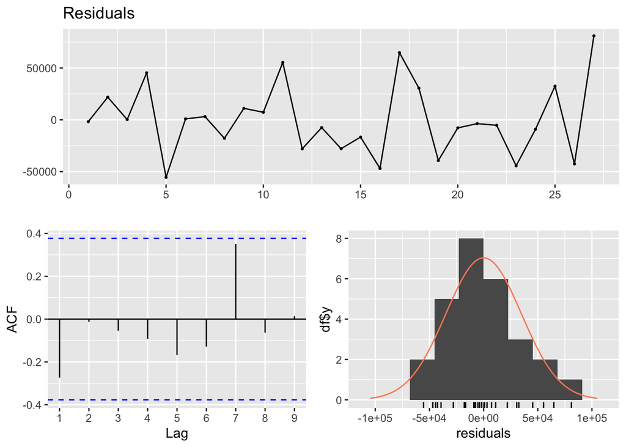

```r
checkresiduals(modelFinal$residuals)
```

We can check the model validity from residuals that have fair auto-correlation and seem to be normally distributed. So, we can continue with this model. (Additionally the predicted values and the actual data is compared in a same graph which I will add separately to my journal, it work on R-studio but couldn’t work on HTML format unfortunatelly)

## 4) Forecasting With Regression

Prediction of remaining four quarters’ sales:

```r
pred_2007= data_UGS[29:32,c("Quarter","Trend","RNUV","NLPG","GNPA","UGSlag1")]
prediction = c(0,0,0,0)

for(i in 1:4) {
  prediction[i] = predict(modelFinal,newdata = pred_2007[i,])
  if(i<4){pred_2007[i+1,"UGSlag1"] = prediction[i] }
}
prediction
```

```
## [1] 678923.6 796585.9 952886.1 736609.5
```

## 5) Conclusion

The aim of this homework was analyzing UGS data with respect to several independent variables and forecasting its sales for every quarter of 2007 by using time series regression methods. In the end, my selected model suggested that UGS depends on seasonality, trend, RNUV, NLPG, GNPA and lag value.